# Introducción al análisis de datos con R: Clase 5

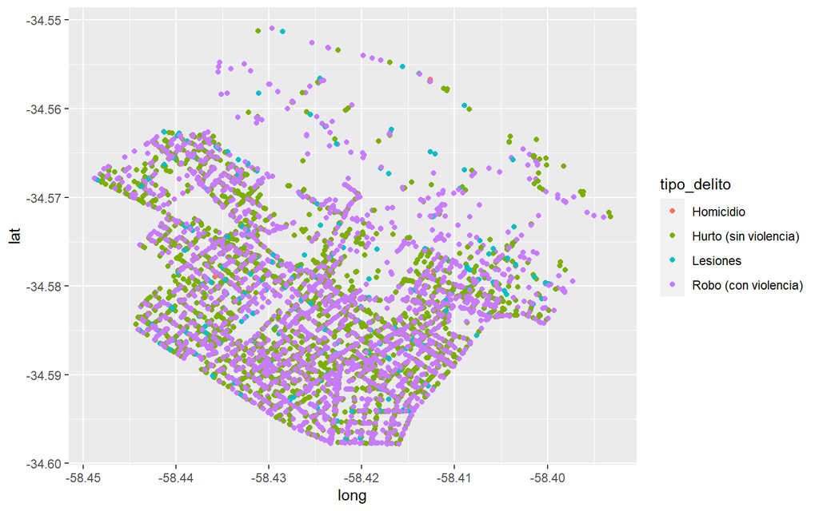

```r
plot_delitos_por_tipo<-ggplot(base%>%
                                filter(barrio=="Palermo"),
                              aes(x=long, y=lat, color=tipo_delito))+
                              geom_jitter()
plot_delitos_por_tipo
```

E. Del mismo modo, podríamos agregar una cuarta variable con el recurso de la forma con el parámetro **shape**:

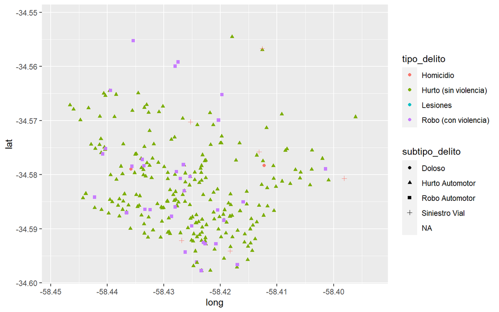

```r
plot_delitos_por_tipo<-ggplot(base%>%
                                filter(barrio=="Palermo"),
                              aes(x=long, y=lat, color=tipo_delito, shape=subtipo_delito))+
  geom_point()
plot_delitos_por_tipo
```

F. Podemos customizar aspectos estéticos del gráfico. Por ejemplo, cambiar el tamaño de los puntos dentro de la función `geom_point()`

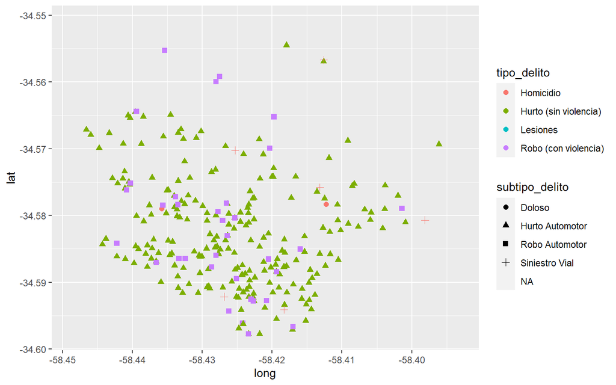

```r
plot_delitos_por_tipo<-ggplot(base%>%
                                filter(barrio=="Palermo"),
                              aes(x=long, y=lat, color=tipo_delito, shape=subtipo_delito))+
  geom_point(size=2)
plot_delitos_por_tipo
```

G. O cambiar el tamaño de los puntos para destacar alguna variable en particular con **size** dentro del `aes()`:

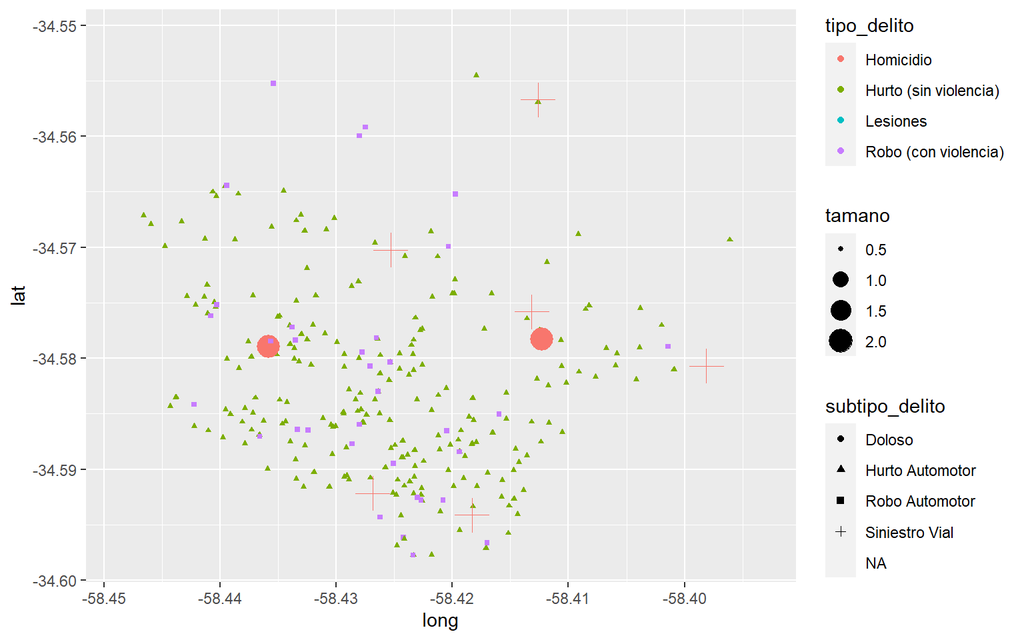

```r
plot_delitos_por_tipo<-ggplot(base%>%
                                filter(barrio=="Palermo")%>%
                                #creamos la variable con el tamaño de los puntos
                                mutate(tamano=case_when(
                                  tipo_delito=="Homicidio"~2,
                                  tipo_delito=="Robo (con violencia)"~.5,
                                  tipo_delito=="Hurto (sin violencia)"~.5,
                                  tipo_delito=="Lesiones"~1)),
                              #incorporamos el tamaño
                              aes(x=long,
                                  y=lat,
                                  color=tipo_delito,
                                  shape=subtipo_delito,
                                  size=tamano))+
  geom_point()

plot_delitos_por_tipo
```

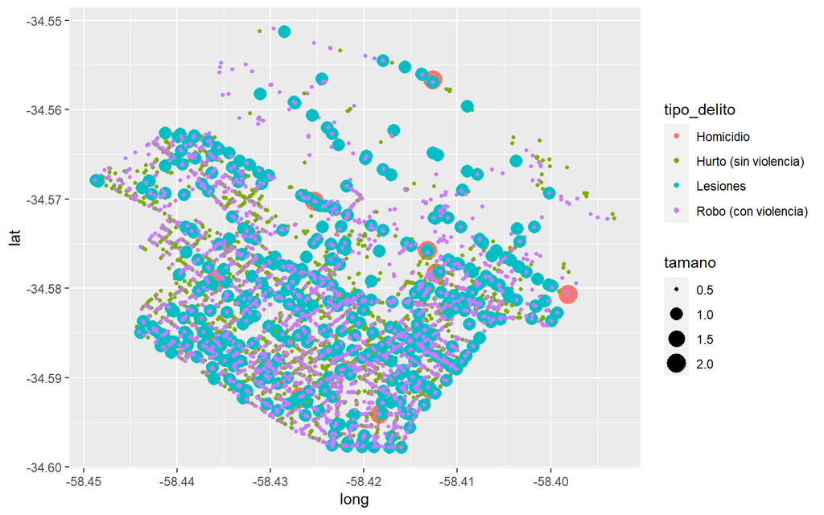

```r
# podríamos usar ifelse en vez de case_when
plot_delitos_por_tipo<-ggplot(base%>%
                                filter(barrio=="Palermo") %>%
                                mutate (tamano =ifelse(tipo_delito=="Homicidio", 2,
                                                       ifelse(tipo_delito == "Lesiones",1, .5))),
                              aes(x=long,
                                  y=lat,
                                  color=tipo_delito,
                                  # shape=subtipo_delito,
                                  size= tamano)) +
  geom_point()
plot_delitos_por_tipo
```

H. Ahora cambiemos la transparencia de los puntos con **alpha** y agreguemos título, subtítulo y epígrafe dentro de `labs()`:

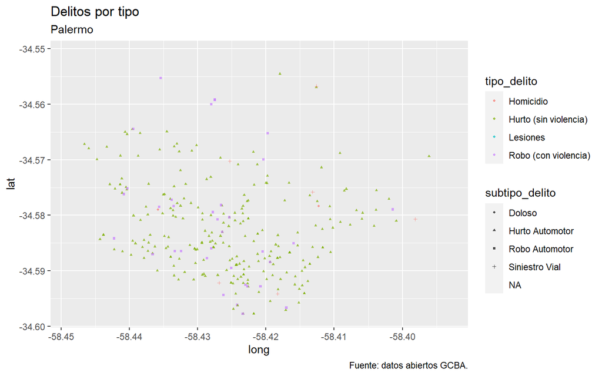

```r
plot_delitos_por_tipo<-ggplot(base%>%
                                filter(barrio=="Palermo"),
                                aes(x=long, y=lat,color=tipo_delito, shape=subtipo_delito)) +
                                geom_point(size=0.75, alpha=0.7) +
                                labs(title = "Delitos por tipo",
                                      subtitle = "Palermo",
                                      caption = "Fuente: datos abiertos GCBA.")
plot_delitos_por_tipo
```

I. Modifiquemos el tema del gráfico con `theme_minimal()` y otros labels en `labs()`:

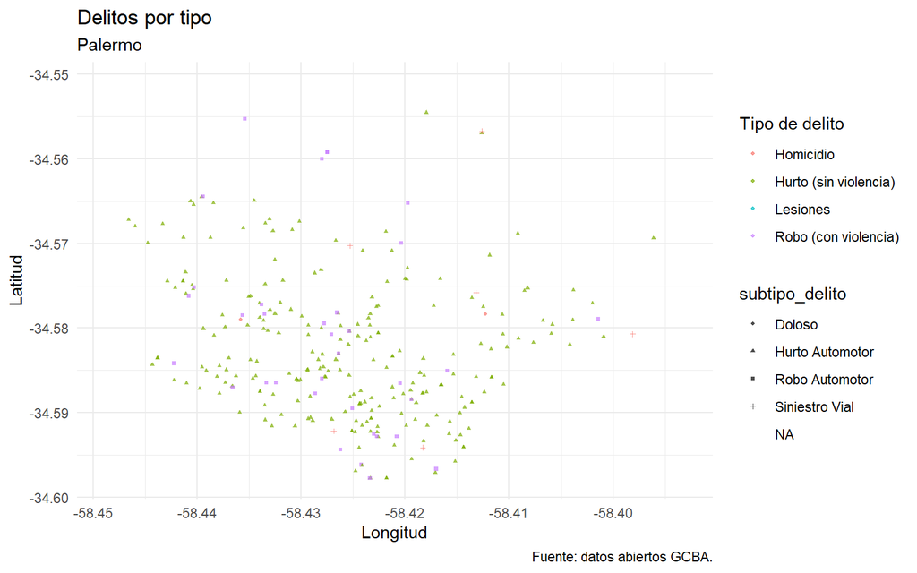

```r
plot_delitos_por_tipo<-ggplot(base%>%
                                filter(barrio=="Palermo"),
                                aes(x=long, y=lat,color=tipo_delito, shape=subtipo_delito)) +
                                geom_point(size=0.75, alpha=0.7) +
                                theme_minimal() +
                                labs(x="Longitud",
                                     y="Latitud",
                                     color="Tipo de delito",
                                     title = "Delitos por tipo",
                                     subtitle = "Palermo",
                                     caption = "Fuente: datos abiertos GCBA.")
plot_delitos_por_tipo
```

J. Cambiemos los colores de los puntos 🖌

Se pueden usar librerías como las de [Brewer](https://r-graph-gallery.com/38-rcolorbrewers-palettes.html) o las de [Viridis](https://cran.r-project.org/web/packages/viridis/vignettes/intro-to-viridis.html), aunque también se puede hacer de forma manual como veremos más adelante 😉

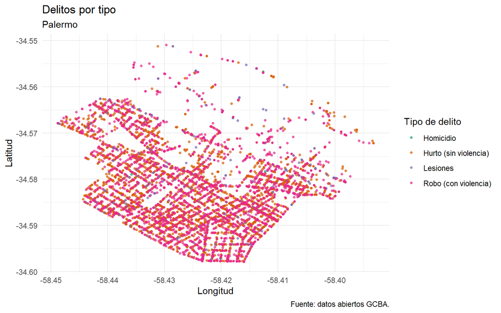

```r
# una paleta de brewer
plot_delitos_por_tipo<-ggplot(base%>%
                                filter(barrio=="Palermo"),
                                 aes(x=long, y=lat,color=tipo_delito)) +
                                  geom_point(size=1, alpha=0.7)+
                                  theme_minimal()+
                                  scale_color_brewer(palette = "Dark2")+
                                  labs(x="Longitud",
                                           y="Latitud",
                                           color="Tipo de delito",
                                           title = "Delitos por tipo",
                                           subtitle = "Palermo",
                                           caption = "Fuente: datos abiertos GCBA.")
plot_delitos_por_tipo
```

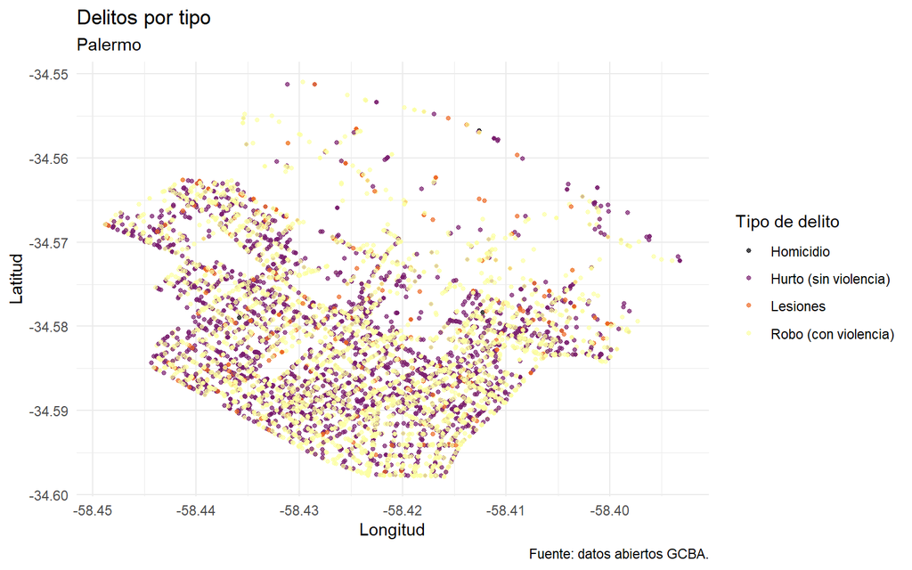

```r
# una paleta de viridis
#install.packages("viridis")
plot_delitos_por_tipo<-ggplot(base%>%
                                filter(barrio=="Palermo"),
                                 aes(x=long, y=lat,color=tipo_delito)) +
                                  geom_point(size=1, alpha=0.7)+
                                  theme_minimal()+
                                  viridis::scale_color_viridis(option = "inferno", discrete = T)+
                                  labs(x="Longitud",
                                           y="Latitud",
                                           color="Tipo de delito",
                                           title = "Delitos por tipo",
                                           subtitle = "Palermo",
                                           caption = "Fuente: datos abiertos GCBA.")
plot_delitos_por_tipo
```

K. Por último, podemos generar gráficos particulares por alguna otra variable de corte con `facet_wrap()`. Por ejemplo, por barrio.

```r
library(viridis)
```

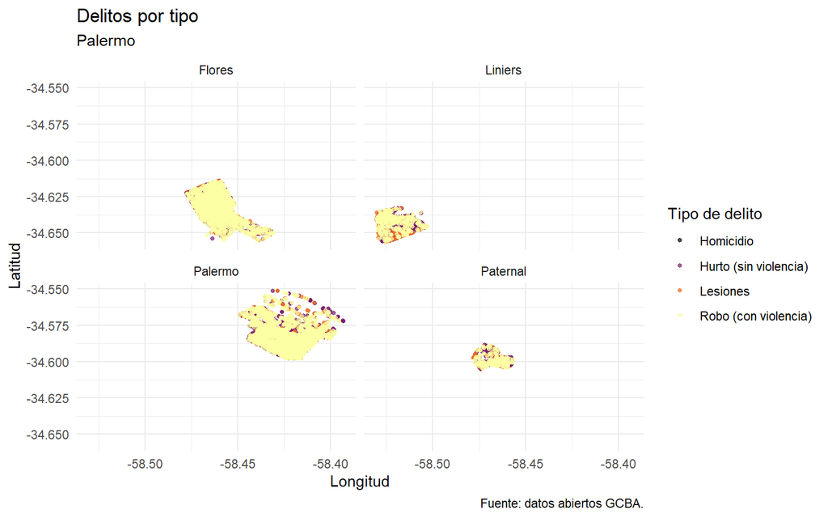

```r
plot_delitos_por_tipo<-ggplot(base%>%
                                filter(barrio%in%c("Palermo", "Paternal", "Flores","Liniers")),
                                       aes(x=long, y=lat,color=tipo_delito))+
                                  geom_point(size=1, alpha=0.7)+
                                  theme_minimal()+
                                  scale_color_viridis(option = "inferno", discrete = T)+
                                  facet_wrap(~barrio)+
                                  labs(x="Longitud",
                                       y="Latitud",
                                       color="Tipo de delito",
                                       title = "Delitos por tipo",
                                       subtitle = "Palermo",
                                       caption = "Fuente: datos abiertos GCBA.")
plot_delitos_por_tipo
```

### 3.2 Barplot - Gráfico de barras

A. `geom_bar()`.

Más info sobre el parámetro [position](https://bookdown.dongzhuoer.com/hadley/ggplot2-book/position.html)

```r
delitos_por_comuna<- base %>%
                      group_by(comuna, tipo_delito)%>%
                      summarise(cantidad=n())
```

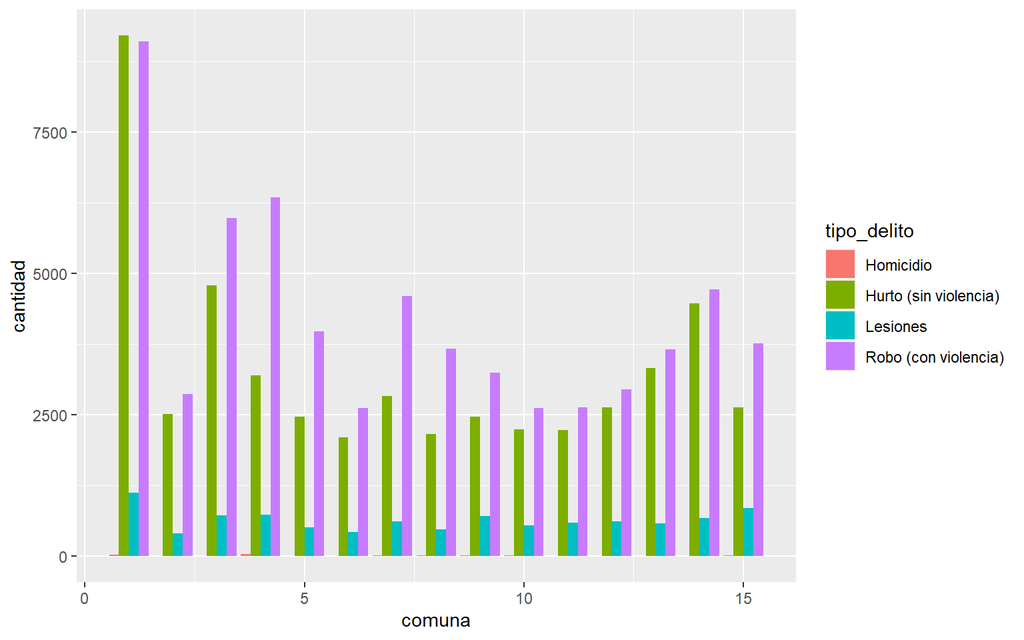

```r
plot_delitos_por_comuna <- ggplot(delitos_por_comuna,
                                aes(x=comuna, y=cantidad, fill=tipo_delito))+
                                geom_bar(stat="identity", #deja los datos como estan
                                         position = "dodge") #barras lado a lado

plot_delitos_por_comuna
```

B. Mejoremos un poco el gráfico: - **reorder** en el `aes()` - `coord_flip()` para voltear el gráfico - `scale_y_continuous()` para definir la escala del eje y - **element_text** dentro **axis.text.y** en el `theme()` para customizar la tipografía del eje y

```r
delitos_por_comuna<-base %>%
            group_by(comuna, tipo_delito) %>%
            summarise(cantidad = n()) %>%
            ungroup()%>%
            filter(!is.na(comuna))%>% #quitamos los valores no asignados (NA)
            mutate(comuna=as.factor(comuna)) #tranformamos a factor la variable comuna
unique(base$tipo_delito)
```

```
## [1] "Robo (con violencia)"  "Hurto (sin violencia)" "Homicidio"
## [4] "Lesiones"
```

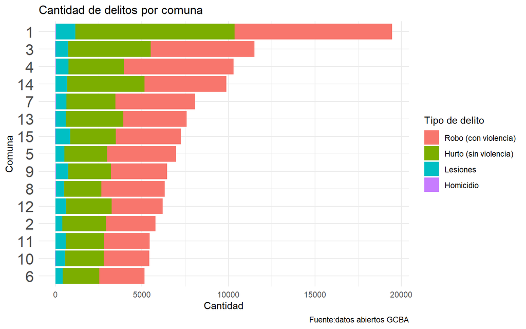

```r
plot_delitos_por_comuna <- ggplot(delitos_por_comuna,
                           aes(x=reorder(comuna,cantidad),#reordenamos de mayor a menor
                               y=cantidad,
                               fill=factor(tipo_delito,
                                           levels = c("Robo (con violencia)",
                                                      "Hurto (sin violencia)",
                                                      "Lesiones",
                                                      "Homicidio")))) +
                              geom_bar(stat="identity", position = "stack")+
                              #geom_bar(stat="identity", position = "dodge") +
                              # geom_bar(stat="identity", position = "fill")+
                              coord_flip()+ #"volteamos" el grafico
                              #scale_y_continuous(n.breaks = 10)+
                              theme_minimal()+ #usamos un tema
                              theme(axis.text.y = element_text(size = 17))+ #agrandamos los numeros
                              labs(x="Comuna", y="Cantidad",
                                   title = "Cantidad de delitos por comuna",
                                   caption = "Fuente:datos abiertos GCBA",
                                   fill="Tipo de delito") #agregamos labels
plot_delitos_por_comuna
```

### 3.3. Linebar - Gráfico de líneas

`geom_line()` y `geom_smooth()`

```r
head(base,10)
```

```
## # A tibble: 10 × 10
##         id fecha    franja_h…¹ tipo_…² subti…³ canti…⁴ comuna barrio   lat  long
##      <dbl> <chr>    <chr>      <chr>   <chr>     <dbl>  <dbl> <chr>  <dbl> <dbl>
##  1 1038983 13-09-19 14         Robo (… <NA>         NA      6 Cabal… -34.6 -58.5
##  2 1038986 13-09-19 16         Robo (… <NA>         NA      3 Balva… -34.6 -58.4
##  3 1038989 13-09-19 13         Robo (… <NA>         NA      3 Balva… -34.6 -58.4
##  4 1038990 13-09-19 16         Robo (… <NA>         NA      3 Balva… -34.6 -58.4
##  5 1038991 13-09-19 11         Robo (… <NA>         NA      1 Monse… -34.6 -58.4
##  6 1038994 13-09-19 14         Robo (… <NA>         NA      1 Monse… -34.6 -58.4
##  7 1038997 13-09-19 23         Robo (… <NA>         NA      6 Cabal… -34.6 -58.4
##  8 1038998 13-09-19 16         Robo (… <NA>         NA      3 Balva… -34.6 -58.4
##  9 1039000 13-09-19 17         Robo (… <NA>         NA      3 Balva… -34.6 -58.4
## 10 1039006 13-09-19 22         Robo (… <NA>         NA      3 Balva… -34.6 -58.4
## # … with abbreviated variable names ¹franja_horaria, ²tipo_delito,
## #   ³subtipo_delito, ⁴cantidad_registrada
```

```r
# creamos DF
delitos_por_fecha<-base %>%
  filter(!franja_horaria == "S/D")%>%
  #ajustamos tipos de datos
  mutate(tipo_delito = as.factor(tipo_delito),
         fecha=dmy(fecha),
         horario=as.numeric(franja_horaria)) %>%
  group_by(fecha, tipo_delito)%>%
  summarise(cantidad=n())
chequeo <- is.na(base$fecha) %>% as.data.frame()

head(delitos_por_fecha)
```

```
## # A tibble: 6 × 3
## # Groups:   fecha [2]
##   fecha      tipo_delito           cantidad
##   <date>     <fct>                    <int>
## 1 2019-01-01 Hurto (sin violencia)       51
## 2 2019-01-01 Lesiones                    18
## 3 2019-01-01 Robo (con violencia)       128
## 4 2019-01-02 Hurto (sin violencia)      110
## 5 2019-01-02 Lesiones                    16
## 6 2019-01-02 Robo (con violencia)       205
```

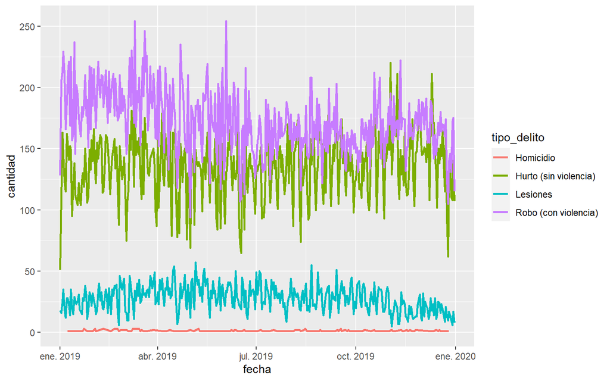

```r
#graficamos evolución de los delitos por fecha, según tipo de delito
plot_delitos_por_fecha<-ggplot(delitos_por_fecha,
                               aes(x=fecha, y=cantidad, color=tipo_delito))+
                        geom_line(size=1, alpha=1)

plot_delitos_por_fecha
```

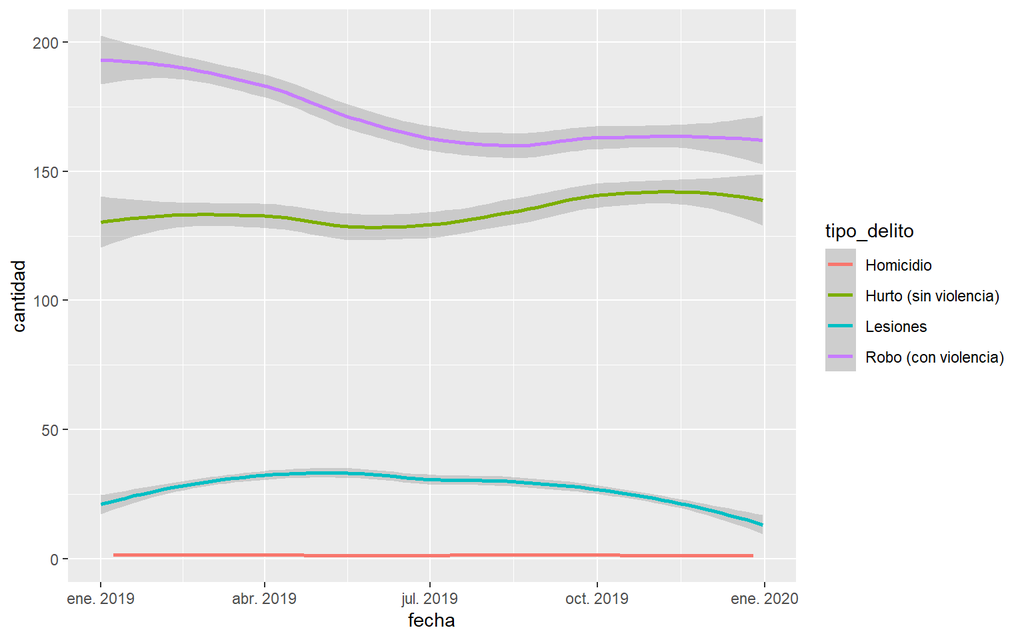

```r
#otra manera de mostrarlo
plot_delitos_por_fecha<-ggplot(delitos_por_fecha,
                               aes(x=fecha, y=cantidad, color=tipo_delito))+
                        geom_smooth()



plot_delitos_por_fecha
```

### 3.4. Pie charts - Gráfico de tortas

Transformamos un gráfico de barras y lo volvemos de torta con `coord_polar(theta = 'y')` para cambiar la geometría.

```r
# creamos DF
base_tipos <- base%>%
                    group_by(tipo_delito)%>%
                    summarise(cantidad=n()) %>%
                    mutate(porcentaje = cantidad / sum(cantidad)) %>% # Agrega columna de porcentaje
                    arrange(-cantidad)                      # Ordena descendente por cantidad

head(base_tipos)
```

```
## # A tibble: 4 × 3
##   tipo_delito           cantidad porcentaje
##   <chr>                    <int>      <dbl>
## 1 Robo (con violencia)     62829    0.513
## 2 Hurto (sin violencia)    49351    0.403
## 3 Lesiones                 10106    0.0825
## 4 Homicidio                  198    0.00162
```

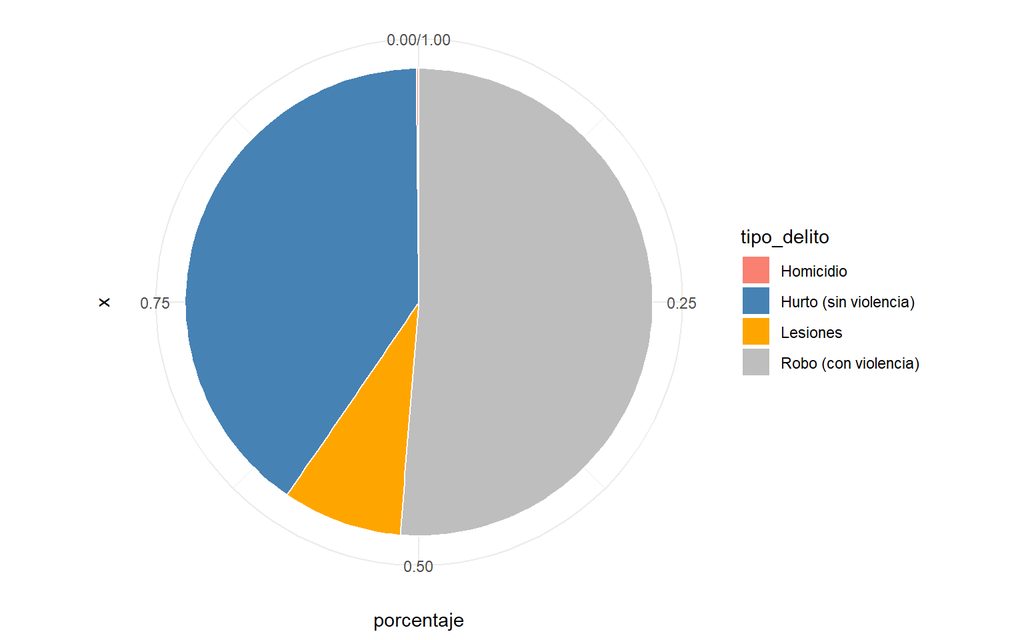

```r
#graficamos evolución de los delitos por franja horaria, según tipo de delito
plot_delitos_tipos <- ggplot(base_tipos,aes(x="",y=porcentaje, fill=tipo_delito))+
  geom_bar(stat = "identity",
           color="white")+
  coord_polar(theta = "y")+
  scale_fill_manual(values=c("salmon","steelblue","orange","gray"))+
    theme_minimal()
plot_delitos_tipos
```

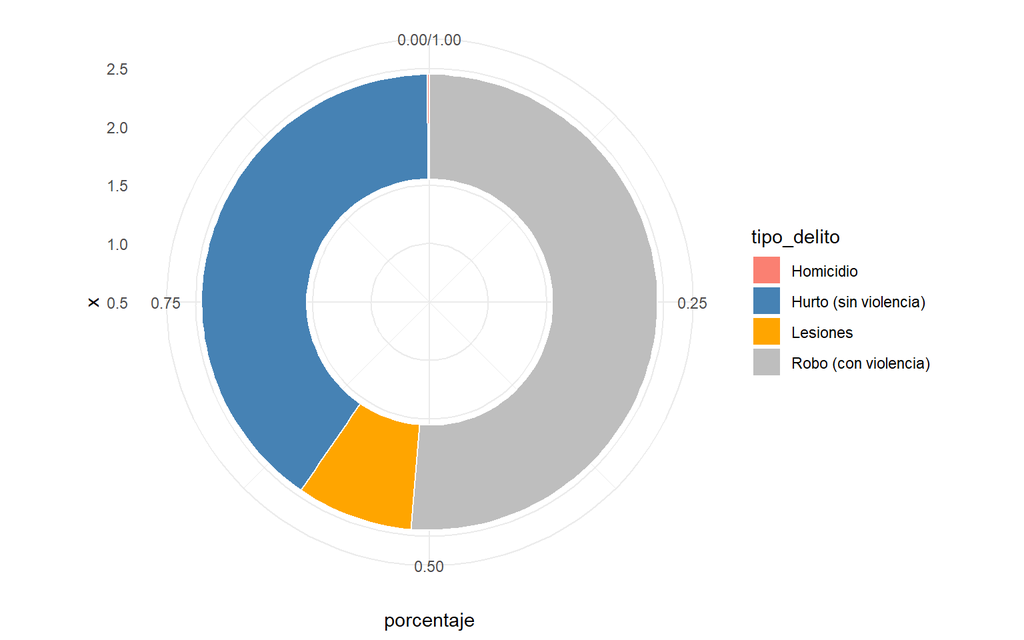

```r
# anillo
ggplot(base_tipos,aes(x=2,y=porcentaje, fill=tipo_delito))+
  geom_bar(stat = "identity",
           color="white")+
  coord_polar(theta = "y")+
  scale_fill_manual(values=c("salmon","steelblue","orange","gray"))+
    theme_minimal()+
  xlim(0.5,2.5)
```

### 3.5 Heat map - Mapa de calor

`geom_tile()`

```r
# Distribución de delitos por día y franja horaria
base_dias_horarios<-base%>%
                    mutate(dia=wday(fecha, label = T),
                     horario=as.numeric(franja_horaria))%>%
                    group_by(dia, horario)%>%
                    summarise(cantidad=n())
```

[output not shown]

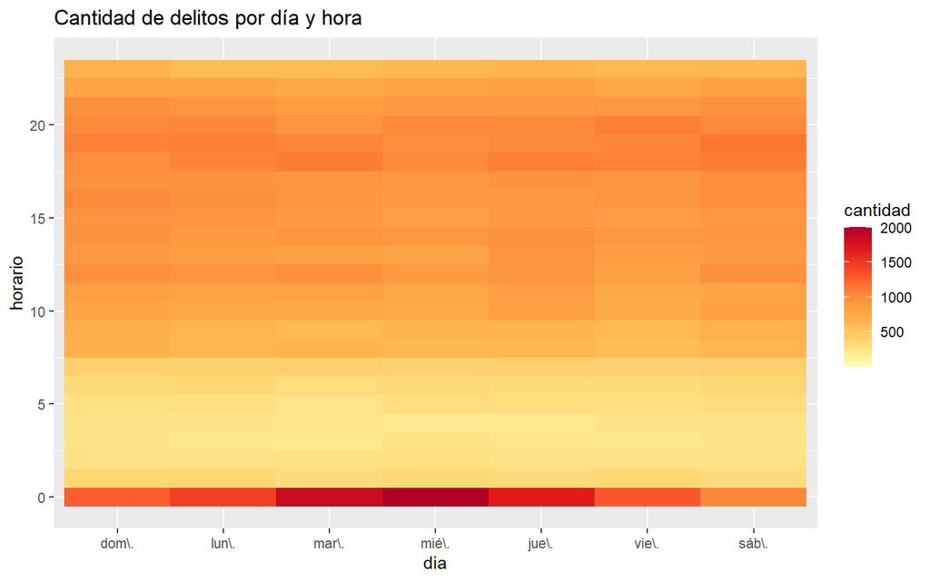

```r
plot_dias_horarios <- ggplot(base_dias_horarios,aes(x=dia, y=horario, fill=cantidad))+
                        geom_tile()+
                        scale_fill_distiller(palette = "YlOrRd", direction = 1)+
                        labs(title="Cantidad de delitos por día y hora")
plot_dias_horarios
```

## 4. Combinaciones y otros ajustes 😏

A. Podemos manipular los gráficos de múltiples formas. Por ejemplo, podemos combinar distintas geometrías. En este caso, probemos combinar líneas y puntos. Aquí también incorporamos un neuvo paquete de temas: [ggthemes](https://yutannihilation.github.io/allYourFigureAreBelongToUs/ggthemes/)

```r
base_delitos_fecha_2 <-base%>%
  mutate(fecha=dmy(fecha),
         mes=round_date(fecha, unit = "month")) %>% #redondeamos por mes
  group_by(mes, tipo_delito)%>% #agrupamos por mes
  summarise(cantidad=n())
```

[output not shown]

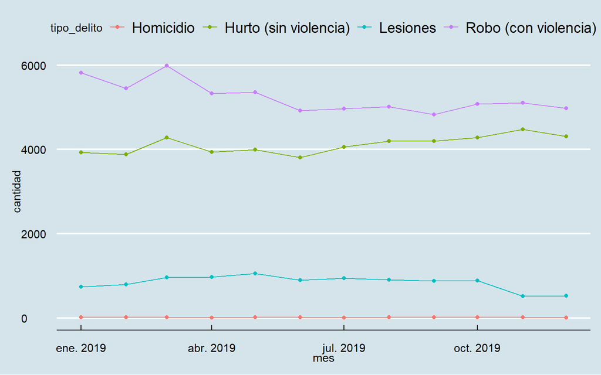

```r
plot_delitos_mes<-ggplot(base_delitos_fecha_2, aes(x=mes, y=cantidad, color=tipo_delito))+
  geom_line()+
  geom_point()+
  # theme_void()
  ggthemes::theme_economist()

plot_delitos_mes
```

B. Ahora vamos a manipular el eje X de un plot anterior con `scale_x_date()`:

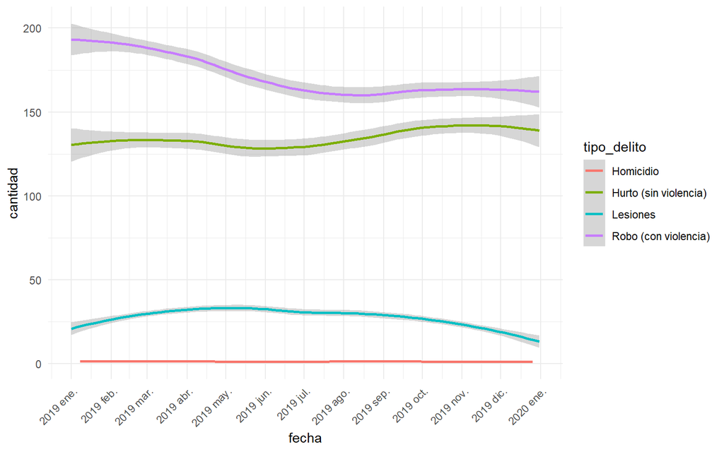

```r
plot_delitos_por_fecha<-plot_delitos_por_fecha+
  scale_x_date(date_breaks = "1 month", date_labels = "%Y %b")+
  # scale_x_date(date_breaks = "3 month", date_labels = "%Y %B %e")+
  theme_minimal()+
  theme(axis.text.x = element_text(angle = 45, hjust = 1))

plot_delitos_por_fecha
```

C. Superpongamos plots:

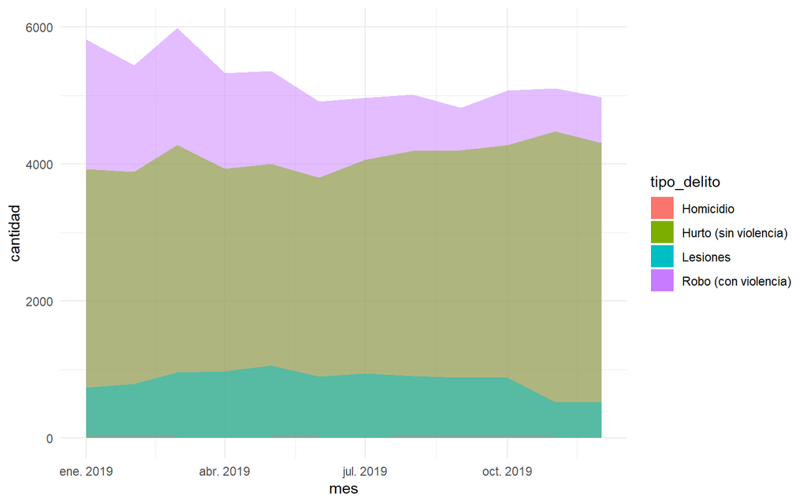

```r
#sumamos graficos de areas sobre una misma base para visualizar los distintos tipos de delitos:

plot_areas<-ggplot()+
  geom_area(data = base_delitos_fecha_2%>%
              filter(tipo_delito=="Robo (con violencia)"),
            mapping = aes(x=mes, y=cantidad,fill=tipo_delito),alpha=0.5)+
  geom_area(data = base_delitos_fecha_2%>%
              filter(tipo_delito=="Hurto (sin violencia)"),
            mapping = aes(x=mes, y=cantidad,fill=tipo_delito),alpha=0.5)+
  geom_area(data = base_delitos_fecha_2%>%
              filter(tipo_delito=="Lesiones"),
            mapping = aes(x=mes, y=cantidad,fill=tipo_delito),alpha=0.5)+
  geom_area(data = base_delitos_fecha_2%>%
              filter(tipo_delito=="Homicidio"),
            mapping = aes(x=mes, y=cantidad,fill=tipo_delito),alpha=1)+
  theme_minimal()+
  labs()
plot_areas
```

D. Por último, podemos setear manualmente los colores del gráfico:

```r
unique(base$tipo_delito) #primero nos fijamos las categorias que tiene la variable
```

```
## [1] "Robo (con violencia)"  "Hurto (sin violencia)" "Homicidio"
## [4] "Lesiones"
```

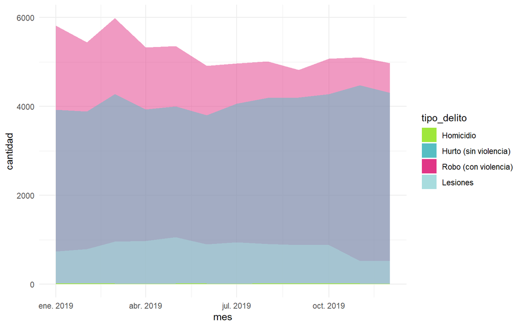

```r
colores_tipo_delito<-c("Homicidio"="#9FE73B",
                       "Hurto (sin violencia)"="#57BEC3",
                       "Robo (con violencia)"="#E13586",
                       "Lesiones"="#A7DCDE") #definimos los colores a usar

plot_areas_2<-plot_areas+
  scale_fill_manual(values = colores_tipo_delito)
plot_areas_2
```

## 5. Finalmente, guardemos nuestros plots

```r
#dir.create("../plots")
#path_plots<-("../plots")

# ggsave(filename = "1 Cantidad de delitos por comuna.png",
#        plot = plot_delitos_por_comuna,
#        device = "png",
#        path = path_plots,
#        width = 20,
#        height = 15,
#        units = "cm")
```

## Práctica

1. Visualizar los 10 barrios con mayor cantidad de homicidos:
2. Visualizar la evolución de delitos a lo largo del año de la Comuna 1 vs la Comuna 3:
3. Visualizar los delitos que ocurren por horario y día según cada tipo de delito:
4. Visualizar cuál es el día de la semana en el que ocurren menos delitos (pista: usar lubridate para tranformar la variable fecha y que nos muestre el día de la semana):

5- Visualizar la ubicación de los robos en el barrio Agronomía: